# Predicting How Well an Activity was Performed

Jayesh Samant

January 16, 2017

## Executive Summary

The objective of this paper is to predict how well an activity was performed using the data collected from the accelerometers on the belt, forearm, arm, and dumbell. To perform this analysis we first load and transform the training data set to include only the relevant columns. We then build a simple classification tree to aid in the inference and then build a prediction tree using random forest algorithm. We use the random forest model to predict the outcome on the test data.

## Data Loading

We first download the training and the test data from the provided locations. The training and test data frames are then loaded into memory.

```r
## Download the training and the test data
#download.file("https://d396qusza40orc.cloudfront.net/predmachlearn/pml-training.csv", "training_data.csv")
#download.file("https://d396qusza40orc.cloudfront.net/predmachlearn/pml-testing.csv", "testing_data.csv")

## Load the training and test data frames into memory
training <- read.csv("training_data.csv")
testing <- read.csv("testing_data.csv")
```

The training data set is composed of 19622 rows and 160 columns. While the test data set of composed of 20 rows and 160 columns.

## Data Transformation

```r
## countnas identifies the proportion of entries in its arguments which are NA
countnas <- function(x) { sum(is.na(x)) / length(x)}

## For each column in training determine the proportion of entries which are NA
result <- apply(training, 2, countnas)
table(result)
```

```
## result
##                 0 0.979308938946081
##                93                67
```

```r
## Include only the columns which have no NAs in the model building exercise
columns <- names(subset(result, result == 0))
training_final <- training[, columns]
```

The reduced training data set now has only 93 columns.

However the reduced training dataset still contains a number of columns which contain a majority of blank values. There columns are of the form * kurtosis_roll_  
* kurtosis_picth * kurtosis_yaw  
* skewness_roll  
* skewness_yaw_  
* skewness_pitch  
* max_yaw  
* min_yaw  
* amplitude_yaw

We identify these columns and eliminate these from the training dataset.

```r
asFactors <- which(grepl("^kurtosis_roll_|^kurtosis_picth|^kurtosis_yaw|^skewness_roll|^skewness_roll_|^skewness_yaw_|^max_yaw|^min_yaw|^amplitude_yaw|^skewness_pitch", names(training_final)))
training_final <- training_final[,-asFactors]
```

The reduced training data set now has only 60 columns.

We also eliminate the first seven columns of the training dataset. These columns refer to the record number, username, timestamps etc. which should not be part of the model.

```r
training_final <- training_final[,-(1:7)]
```

We use this training_final dataset with 53 columns for building the prediction model.

## Inference Model

We first build a simple model to draw some inferences on the data. We use the classification tree to create the simple model.

```r
infModel <- tree(classe~., data = training_final)
summary(infModel)
```

```
##
## Classification tree:
## tree(formula = classe ~ ., data = training_final)
## Variables actually used in tree construction:
##  [1] "roll_belt"            "pitch_forearm"        "roll_forearm"
##  [4] "magnet_dumbbell_x"    "magnet_dumbbell_y"    "magnet_dumbbell_z"
##  [7] "pitch_belt"           "yaw_belt"             "accel_dumbbell_x"
## [10] "accel_dumbbell_z"     "total_accel_dumbbell" "accel_forearm_x"
## Number of terminal nodes:  18
## Residual mean deviance:  1.684 = 33010 / 19600
## Misclassification error rate: 0.3324 = 6522 / 19622
```

The five most important predictors are roll_belt, pitch_forearm, roll_forearm, magnet_dumbbell_x, magnet_dumbbell_y. The model has 18 leaf nodes. The total misclassification error rate for this model is 33.24%. which is quite high.

The plot of the resulting classification tree is shown below.

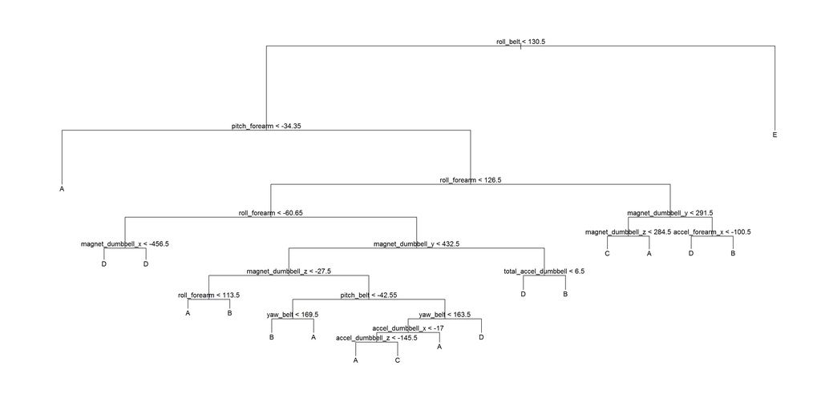

```r
plot(infModel)
text(infModel)
```

we run some cross-validations on the training data to determine the optimum size of the classification tree.

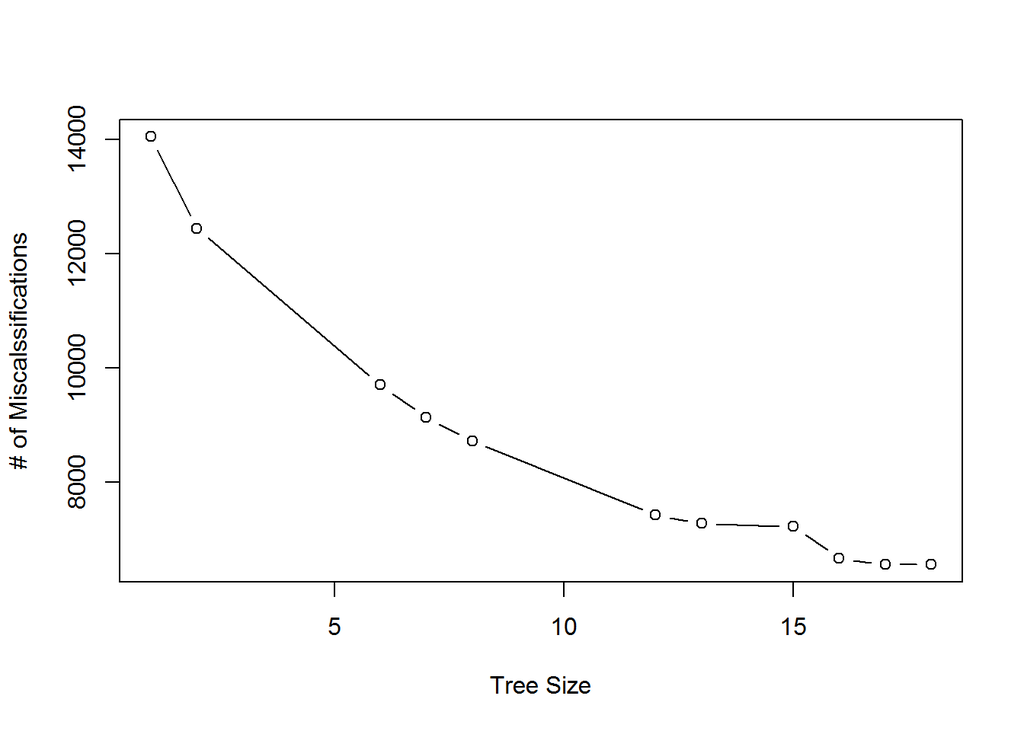

```r
cvTree <- cv.tree(infModel, FUN = prune.misclass)
plot(cvTree$size, cvTree$dev, xlab = "Tree Size", ylab = "# of Miscalssifications", type="b")
```

We can see that the size of 18 return the minimum number of misclassifications and hence there is no further reason for pruning the tree.

## Prediction Model

With an training error rate of 33.24%, the simple tree for inference performs badly for prediction. We hence use random forests to select the best prediction model.

```r
predModel <- randomForest(classe~., data = training_final)
predModel
```

```
##
## Call:
##  randomForest(formula = classe ~ ., data = training_final)
##                Type of random forest: classification
##                      Number of trees: 500
## No. of variables tried at each split: 7
##
##         OOB estimate of  error rate: 0.27%
## Confusion matrix:
##      A    B    C    D    E  class.error
## A 5577    2    0    1    0 0.0005376344
## B    8 3785    4    0    0 0.0031603898
## C    0   13 3407    2    0 0.0043834015
## D    0    0   17 3198    1 0.0055970149
## E    0    0    1    4 3602 0.0013861935
```

The below diagram shows the predictors considered in the model and their importance.

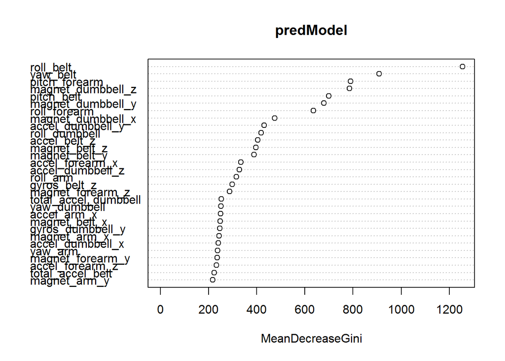

```r
varImpPlot(predModel)
```

## Test Set Prediction

```r
preds <- predict(predModel, newdata = testing)
```

The predictions on the twenty records in the test set are as follows: B, A, B, A, A, E, D, B, A, A, B, C, B, A, E, E, A, B, B, B.